# Project 4

Visualising data about videos from the YouTube channels Disney and Pixar

YIxuan Liu

2024-05-07

## Introduction

I choose two channel (Disney and Pixar) in YouTuBe, I want to do a search on how these two channel going, is there any relationship between the like and view in each channel, can date be the influence element of likes based on two channel, will the duration of each video published over time for each channel. Before I start to visualising data, I need to select the data that I need to focused on, likes and views can help me to solve the first question i wanna to know, channel name, duration, and date are also the variables that I need during solving the plot and deal with the data. I plan to use a bar plot, a point plot and a line chart, as bar plot can easy comparison across categories and supporting effective data storytelling, the point plot and line chart can easily show the trend.

During visualising data and making plot, I try to draw a bar plot and the x-axis is date(year from 2020 - 2024) and y_axis is the likes, based on each group, compare the likes in every year for each group. That can easily show the difference between each group every year. But I failed to do this, I wondering that might be something wrong when I grouped my data. And the other question that I met is to fit a suitable size when combine the plot into the slide.

## Dynamic data story

Here is the dynamic data story from the data analysis project:

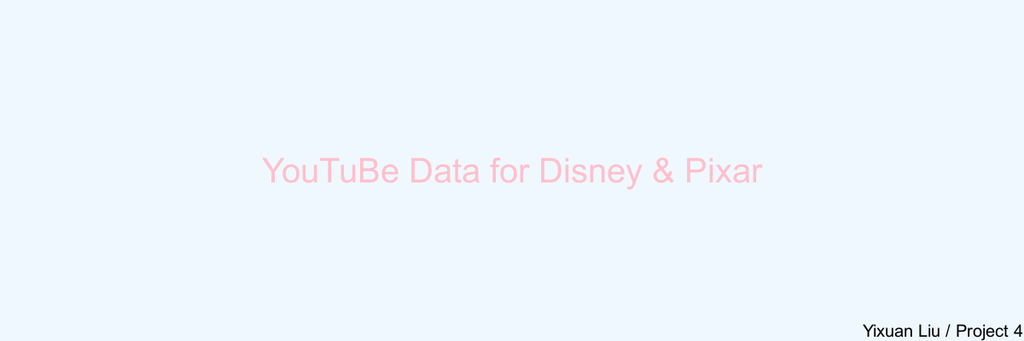

For some code while dealing with the data and drawing plot, I combined the knowledge I learned before or use search sign in Rstudio (?, help).

For creativity, I create a new plot to check if there is a linear relationship between likecount and viewcount. I search the code for draw a line with suitable intercept and slope on the point plot by using “?geom_abline()” and fit a simple linear model to get the intercept and slope, for fitting the model, I learned in stats201 by using “lm()” , and get coefficient by “coef()”.

## Learning reflection

The most important ideal that I learn in module 4 is to visualise the data by using ggplot() function, many plot can be drew by ggplot(), the most function that i am interested in is geom_count() and group_by(). Group_by() is quit useful when we want group the data and combine with the function summaries() can get the summary data and show as a clear matrix. By using these functions, and combined with other two modules before, I can explore more data in different ways and type.

The thing that I want to know more is Artificial Intelligence (AI) and Machine Learning (ML), I want to know how AI and ML models make decisions and providing transparency in model outcomes, and advancements in neural networks, such as transformers, and their applications across domains.

## Appendix

```r
library(tidyverse)
library(ggplot2)

youtube_data  <- read_csv("https://docs.google.com/spreadsheets/d/e/2PACX-1vSKjldOzOg5grnUfnfbcdfGuFNKOvbXnC344sZSddtBtwkjWyFbM0X-AOFR2g5MRxTT-S5s7RKOO1jh/pub?output=csv")

glimpse(youtube_data)

# data select
data <- youtube_data %>%
  select(channelName,viewCount,likeCount,duration,datePublished) %>%
  mutate(date = case_when(str_detect(datePublished,"2020") ~ '2020',
                          str_detect(datePublished,"2021") ~ '2021',
                          str_detect(datePublished,"2022") ~ '2022',
                          str_detect(datePublished,"2023") ~ '2023',
                          str_detect(datePublished,"2024") ~ '2024',
                          TRUE ~ "other"),
         channel = ifelse(str_detect(channelName,"Disney"),"Disney","Pixar")
         )



# Plot 1: relationship between number of views and the number of likes for each channel (Disney and Pixar)
# get the top 100 views
sorted_data <- data %>%
  arrange(desc(data$viewCount)) %>%
  slice(1:100) %>%
  select(channel,viewCount,likeCount)

plot1 <- ggplot(sorted_data,aes(x=viewCount,y=likeCount,colour = channel)) +
  geom_count(pch = 16) +
  scale_color_manual(values = c("Disney" = "skyblue", "Pixar" = "lightpink")) +
  labs(title='top 100 in views and likes') +
  theme(plot.title = element_text(hjust = 0.5)) ## Center the title
ggsave(filename = "plot1.png", plot = plot1)


# Plot 2: relationship between the like count and years, grouped by Disney and Pixar
genre_date <- data %>%
  group_by(date) %>%
  select(channel,date,likeCount)

plot2 <- genre_date %>%
  ggplot() +
  geom_col(aes(x=likeCount,y=date,fill = channel)) +
  labs(title = "LikeCount V.s. Year",
       y = "year") +
  scale_fill_manual(values = c("Disney" ="#87CEFA", "Pixar" = "pink"))


ggsave(filename = "plot2.png", plot = plot2)

# Plot3 : mean duration over time for each channel (Disney and Pixar)
summary_data <- data %>%
  group_by(date,channel) %>%
  summarise(mean_duration = mean(duration, na.rm = TRUE))

plot3 <- ggplot(data = summary_data, aes(x = date, y = mean_duration, color = channel, group = channel)) +
  geom_line(linewidth = 1) +
  geom_point(size = 3) +
  labs(title = "Mean Duration Over Time by Channel",
       x = "Date",
       y = "Mean Duration") +
  scale_color_manual(values = c("Disney" = "lightgreen", "Pixar" = "thistle"),
                     name = "Channel")


ggsave(filename = "plot3.png", plot = plot3)

# Plot 4 : the relationship between likeCount and duration based on the group
model <- lm(data$likeCount ~ data$viewCount)
slope <- coef(model)[2]
intercept <- coef(model)[1]

plot4 <- ggplot(data,aes(x=viewCount, y = likeCount)) +
  geom_point(color = "pink") +
  geom_abline(intercept = intercept, slope = slope, color = "skyblue",size = 3)
ggsave(filename = "plot4.png", plot = plot4)
```

```r
library(magick)
library(tidyverse)
slide1 <- image_blank(width = 1200,
                      height = 400,
                      color = "aliceblue") %>%
  image_annotate(text = "YouTuBe Data for Disney & Pixar",
                 color = "pink",
                 size = 40,
                 gravity = "center") %>%
  image_annotate(text = "Yixuan Liu / Project 4",
                 gravity = "southeast",
                 color = "black",
                 size = 20)

slide2 <- image_read("C:/Users/14580/Documents/Stats220/project4/project4/plot1.png")%>%
  image_scale(600)%>%
  image_extent("1200 x 400",color = "aliceblue")%>%
  image_annotate(text="Relationship between top 100 views and likes
                 for each channel (Disney and Pixar))",
                 size = 20,
                 color = "pink",
                 gravity = "northwest")


slide3 <- image_read("C:/Users/14580/Documents/Stats220/project4/project4/plot2.png")%>%
  image_scale(600)%>%
  image_extent("1200 x 400",color = "aliceblue")%>%
  image_annotate(text="Relationship between the like count and years,
                 grouped by Disney and Pixar)",
                 size = 20,
                 color = "pink",
                 gravity = "northwest")

slide4 <- image_read("C:/Users/14580/Documents/Stats220/project4/project4/plot3.png")%>%
  image_scale(600)%>%
  image_extent("1200 x 400",color = "aliceblue" )%>%
  image_annotate(text="Mean duration over time
                 for each channel (Disney and Pixar)",
                 size = 20,
                 color = "pink",
                 gravity = "northwest")

slide5 <- image_read("C:/Users/14580/Documents/Stats220/project4/project4/plot4.png")%>%
  image_scale(600)%>%
  image_extent("1200 x 400",color = "aliceblue" )%>%
  image_annotate(text="check if the relationship
  between likeCount and viewCount is linear",
                 size = 20,
                 color = "pink",
                 gravity = "northwest")

slide6 <- image_blank(width = 1200,
                      height = 400,
                      color = "aliceblue") %>%
  image_annotate(text = "summary",
                 color = "pink",
                 size = 40,
                 gravity = "northwest") %>%
  image_annotate(text = " I make the comparison between two channel Disney and Pixar,
                 and I made three plot by choosing different variables based on two channel.
                 The first plot shows the relationship between 100 views likes for each channel (Disney and Pixar),
                 there is a an increasing trend in both group, and Disney seems get higher likes than Pixar.
                 The second plot shows the relationship between the like count and years, grouped by Disney and Pixar,
                 in 2023, Disney got more likes than the Pixar, and 2020 seems got the same likes.
                 The third plot I focous on the mean duration over time for each channel (Disney and Pixar),
                 it shows that the mean vedio time of Pixar is longer than t Disney.",
                 color = "pink",
                 size = 20,
                 gravity = "center") %>%
  image_annotate(text = "Yixuan Liu / Project 4",
                 gravity = "southeast",
                 color = "black",
                 size = 20)

animate <- image_animate(c(slide1,slide2,slide3,slide4,slide5,slide6),
                         delay =500)
image_write(animate,"data_story.gif")
```